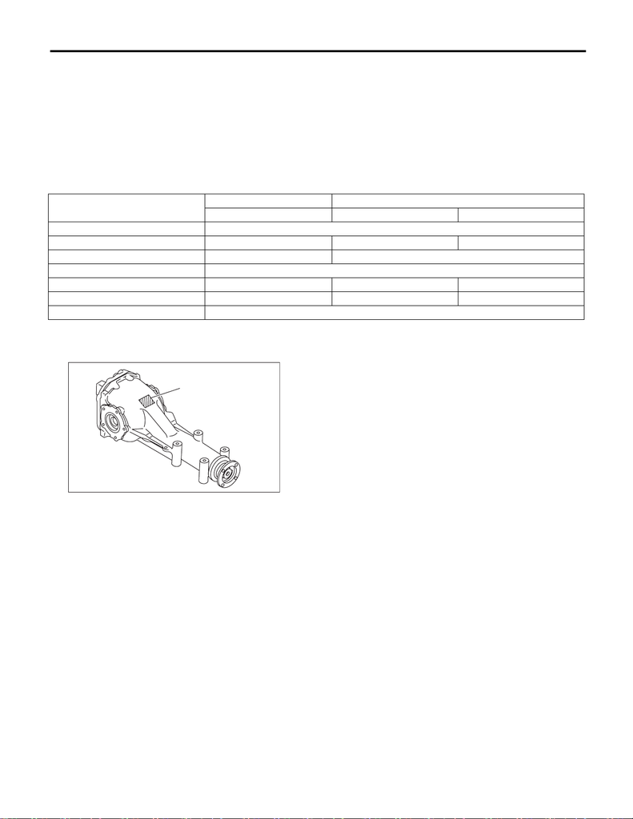

DI-2

General Description

DIFFERENTIALS

1. General Description

A: SPECIFICATION

1. REAR DIFFERENTIAL

When replacing a rear differential assembly, select the correct one according to the following table.

NOTE:

• Using a different rear differential assembly will cause the drive train and tires to drag or emit abnormal

noise.

• For option code, refer to “ID” section. <Ref. to ID-2, IDENTIFICATION, Identification.>

2. IDENTIFICATION

Identification positions are shown in the following figures.

Model

2.5 L high power turbo 2.0 L turbo

6MT 6MT CVT

Rear differential type T-type

Identification H5 B1 B2

LSD type Torsen —

Type of gear Hypoid gear

Gear ratio (number of gear teeth) 3.545 (39/11) 4.111 (37/9) 3.900 (39/10)

Oil capacity 1.0 L (1.1 US qt, 0.9 Imp qt) 0.8 L (0.8 US qt, 0.7 Imp qt) 0.8 L (0.8 US qt, 0.7 Imp qt)

Rear differential gear oil GL-5

(1)

DI-00502

(1) Identification

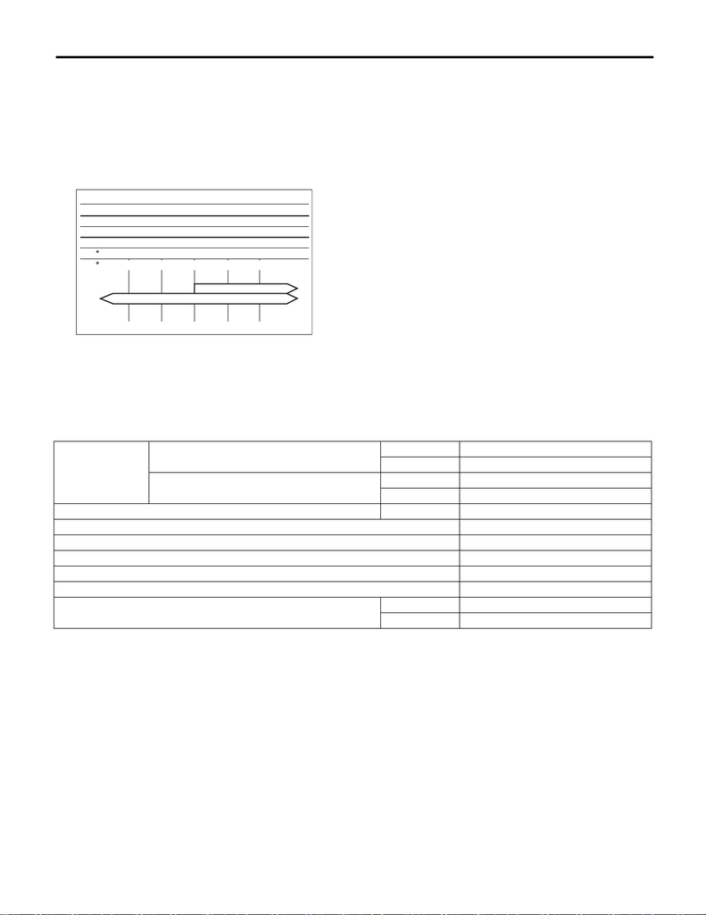

DI-3

General Description

DIFFERENTIALS

3. REAR DIFFERENTIAL GEAR OIL

Recommended gear oil:

GL–5 (75W-90)

Alternative:

Equivalent product

CAUTION:

Each oil manufacturer has its base oil and additives. Thus, do not mix two or more brands.

4. SERVICE DATA

(1)

(4)

GL-5

(3)

(2)

( C)

( F)

-30 -15 15

90

75W -90

30 0

-22 32 86595

MT-03000

(1) Item

(2) Rear differential gear oil

(3) API classification

(4) SAE viscosity No. and applicable temperature

Drive pinion bear-

ing preload (for

new bearing)

Measured with spring measurement (measured

at companion flange bolt hole) N (kgf, lbf)

T-type (B1, B2) 18.1 — 38.8 (1.8 — 4.0, 4.1 — 8.7)

T-type (H5) 24.1 — 38.6 (2.5 — 3.9, 5.4 — 8.7)

Measured with torque wrench N·m (kgf-m, ft-lb)

T-type (B1, B2) 0.69 — 1.47 (0.07 — 0.15, 0.51 — 1.08)

T-type (H5) 0.98 — 1.57 (0.10 — 0.16, 0.72 — 1.16)

Side gear backlash mm (in) T-type (B1, B2) 0.10 — 0.20 (0.004 — 0.008)

Side bearing standard width mm (in) 20.00 (0.7874)

Hypoid driven gear to drive pinion backlash mm (in) 0.10 — 0.20 (0.004 — 0.008)

Hypoid driven gear runout on its back surface mm (in) 0.05 (0.002)

Companion flange mating surface runout mm (in) 0.08 (0.003)

Companion flange runout on its inner surface mm (in) 0.08 (0.003)

Total preload

(measured from the companion flange bolt hole)

N (kgf, lbf)

T-type (B1, B2) 20.7 — 54.4 (2.1 — 5.5, 4.7 — 12.2)

T-type (H5) 26.5 — 53 (2.7 — 5.4, 6.0 — 11.9)

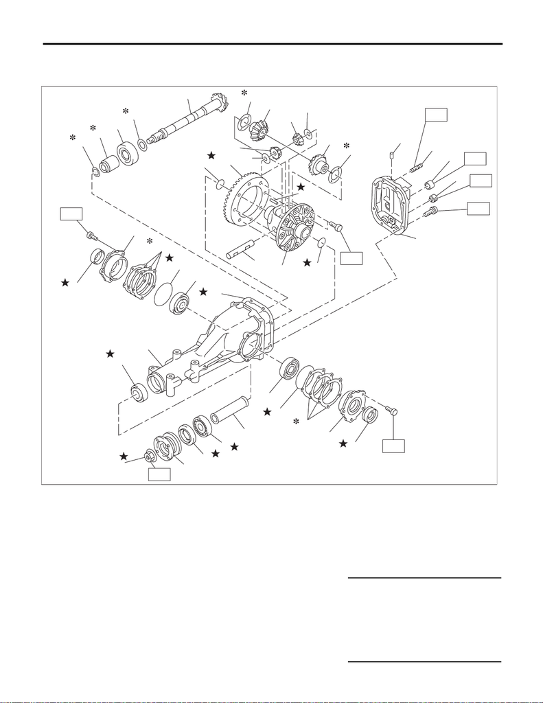

DI-4

General Description

DIFFERENTIALS

B: COMPONENT

1. REAR DIFFERENTIAL (T-TYPE (B1, B2))

(1) Hypoid driven gear and drive pin-

ion set

(14) O-ring (27) Filler plug

(2) Pinion height adjusting washer (15) Side retainer shim (28) Drain plug

(3) Rear bearing (16) Side retainer (29) Rear cover

(4) Preload adjusting spacer (17) Side oil seal (30) Differential case

(5) Preload adjusting washer (18) Side gear thrust washer (31) Gasket

(6) Differential carrier (19) Side gear

(7) Front bearing (20) Pinion mate gear Tightening torque: N·m (kgf-m, ft-lb)

(8) Spacer (21) Pinion mate gear washer T1: 10.5 (1.1, 7.7)

(9) Pilot bearing (22) Pinion shaft lock pin T2: 29.5 (3.0, 21.8)

(10) Front oil seal (23) Snap ring T3: 49 (5.0, 36.1)

(11) Companion flange (24) Pinion mate shaft T4: 103 (10.5, 76.0)

(12) Self-locking nut (25) Air breather cap T5: 181.5 (18.5, 133.9)

(13) Side bearing (26) Stud bolt T6: 44 (4.5, 32.5)

(1)

(1)

(2)

(3)

(4)

(5)

(6)

(7)

(8)

(9)

(10)

(11)

(12)

(13)

(13)

(14)

(14)

(15)

(15)

(16)

(16)

(17)

(17)

(18)

(18)

(19)

(19)

(20)

(20)

(23)

(21)

(21)

(22)

(24)

(30)

(23)

(25)

(26)

(27)

(28)

(29)

(31)

T1

T2

T1

DI-00990

T5

T4

T3

T3

T6

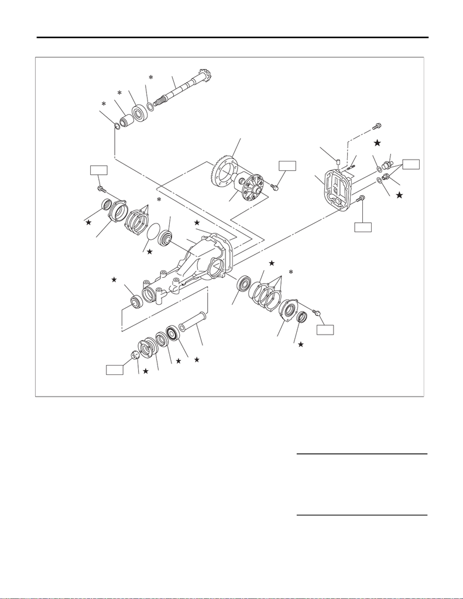

DI-5

General Description

DIFFERENTIALS

2. REAR DIFFERENTIAL (T-TYPE (H5))

(1) Hypoid driven gear and drive pin-

ion set

(12) Self-locking nut (23) Oil temperature sensor

(2) Pinion height adjusting washer (13) Side bearing (24) Drain plug

(3) Rear bearing (14) O-ring (25) Gasket

(4) Preload adjusting spacer (15) Side retainer shim

(5) Preload adjusting washer (16) Side retainer Tightening torque: N·m (kgf-m, ft-lb)

(6) Differential carrier (17) Side oil seal T1: 10.5 (1.1, 7.7)

(7) Front bearing (18) Gasket T2: 44 (4.5, 32.5)

(8) Spacer (19) Differential case ASSY T3: 60 (6.1, 44.3)

(9) Pilot bearing (20) Rear cover T4: 103 (10.5, 76.0)

(10) Front oil seal (21) Air breather cap T5: 181.5 (18.5, 133.9)

(11) Companion flange (22) Stud bolt

T4

T1

T2

(18)

(14)

(5)

(4)

(1)

(21)

(22)

(20)

(19)

(6)

(13)

(16)

(3)

(2)

(1)

(17)

(15)

T1

T5

(13)

(16)

(17)

(12)

(11)

(10)

(9)

(8)

(7)

(14)

(15)

(25)

T3

(25)

(24)

(23)

DI-01002

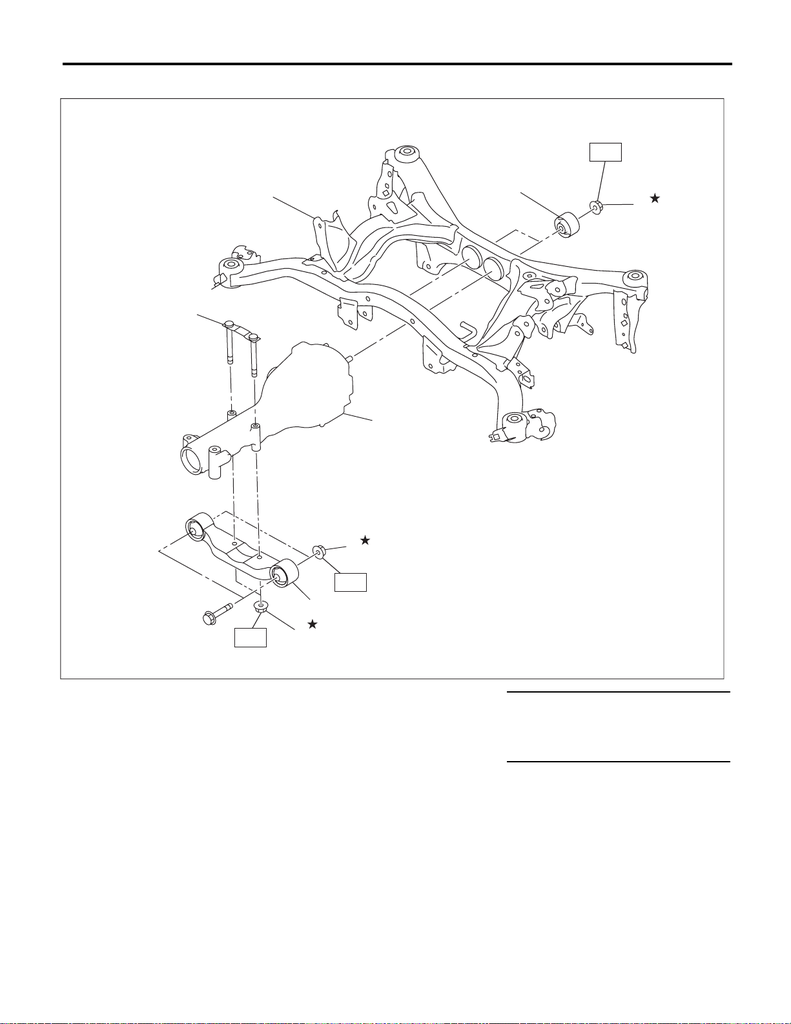

DI-6

General Description

DIFFERENTIALS

3. REAR DIFFERENTIAL MOUNTING SYSTEM

(1) Rear differential front member (4) Rear sub frame Tightening torque: N·m (kgf-m, ft-lb)

(2) Rear differential member plate (5) Rear differential mount bushing T1: 50 (5.1, 36.9)

(3) Rear differential ASSY (6) Self-locking nut T2: 70 (7.1, 51.6)

T3: 110 (11.2, 81.1)

DI-00740

(2)

T3

T1

(1)

(6)

(6)

T2

(6)

(4)

(5)

(3)

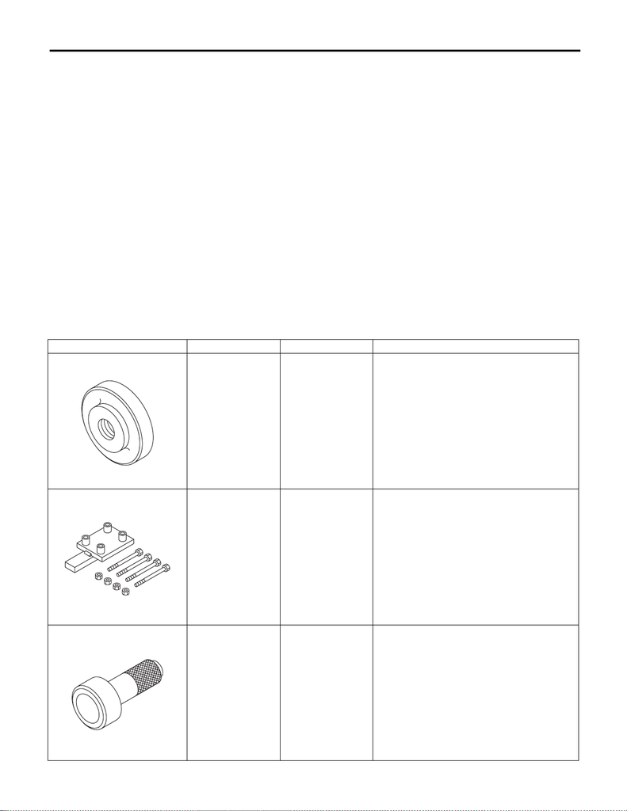

DI-7

General Description

DIFFERENTIALS

C: CAUTION

• Wear appropriate work clothing, including a cap, protective goggles and protective shoes when performing

any work.

• Remove contamination including dirt and corrosion before removal, installation or disassembly.

• Keep the disassembled parts in order and protect them from dust and dirt.

• Before removal, installation or disassembly, be sure to clarify the failure. Avoid unnecessary removal, in-

stallation, disassembly and replacement.

• Vehicle components are extremely hot after driving. Be wary of receiving burns from heated parts.

• Use SUBARU genuine gear oil, grease or equivalent. Do not mix gear oil, grease, etc. of different grades

or manufacturers.

• Be sure to tighten fasteners including bolts and nuts to the specified torque.

• Place shop jacks or rigid racks at the specified points.

• Apply gear oil onto sliding or revolving surfaces before installation.

• Before installing the O-ring or snap ring, apply a sufficient amount of gear oil to avoid damage and defor-

mation.

• Before securing a part on a vise, place cushioning material such as wood blocks, aluminum plate, or cloth

between the part and the vise.

• Avoid damaging the mating surface of the case.

D: PREPARATION TOOL

1. SPECIAL TOOL

ILLUSTRATION TOOL NUMBER DESCRIPTION REMARKS

398477702 DRIFT Used for installing the front bearing race.

398217700 ATTACHMENT SET Stand for rear differential carrier disassembly

and assembly.

498447120 INSTALLER Used for installing the front oil seal.

ST-398477702

ST-398217700

ST-498447120

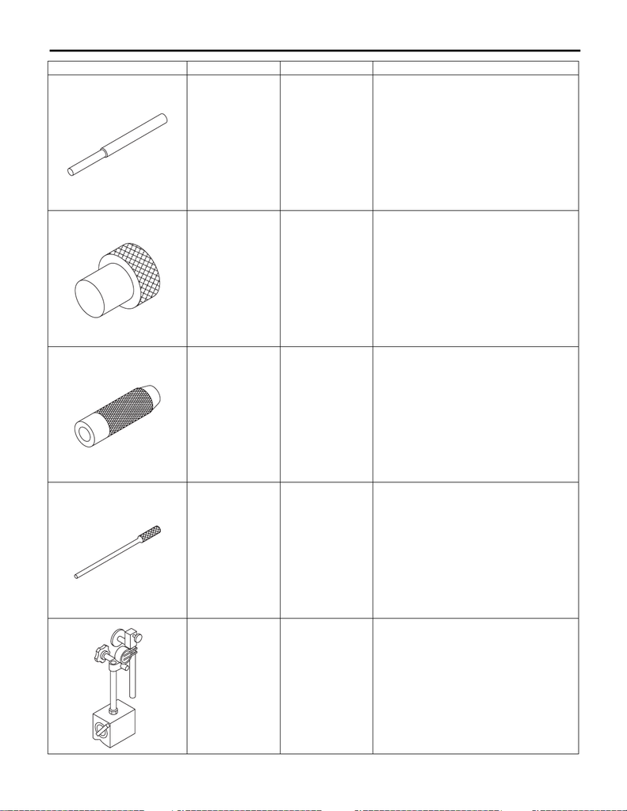

DI-8

General Description

DIFFERENTIALS

398467700 DRIFT Used for removing drive pinion shaft, pilot bear-

ing and front bearing cone.

399780104 WEIGHT • Used for installing the pilot bearing and the

companion flange.

• Used for installing the front bearing cone. (T-

type (B1, B2))

899580100 INSTALLER • Used for installing the pilot bearing.

• Used for installing the front bearing cone. (T-

type (B1, B2))

899904100 STRAIGHT PIN

REMOVER

Used for removing and installing the pinion mate

shaft lock pin. (T-type (B1, B2))

498247001 MAGNET BASE • Used for measuring backlash between side

gear and pinion, and hypoid gear.

• Used together with DIAL GAUGE

(498247100).

ILLUSTRATION TOOL NUMBER DESCRIPTION REMARKS

ST-398467700

ST-399780104

ST-899580100

ST-899904100

ST-498247001

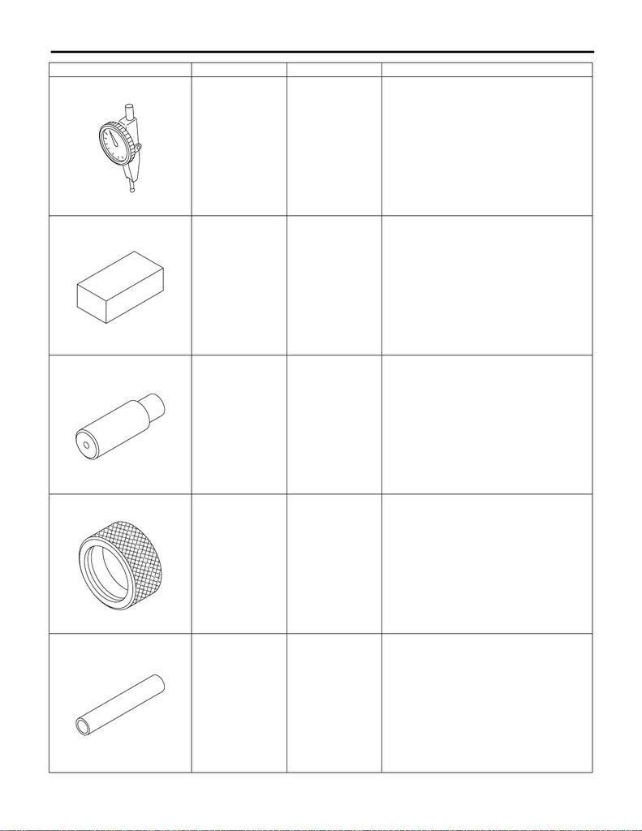

DI-9

General Description

DIFFERENTIALS

498247100 DIAL GAUGE • Used for measuring backlash between side

gear and pinion, and hypoid gear.

• Used together with MAGNET BASE

(498247001).

398507704 BLOCK Used for adjusting pinion height and preload. (T-

type (B1, B2))

398457700 ATTACHMENT Used for removing the side retainer.

398437700 DRIFT Used for installing the side oil seal.

398507703 DUMMY COLLAR • Used for adjusting pinion height and preload.

• Used for installing the front bearing cone.

ILLUSTRATION TOOL NUMBER DESCRIPTION REMARKS

ST-498247100

ST-398507704

ST-398457700

ST-398437700

ST-398507703

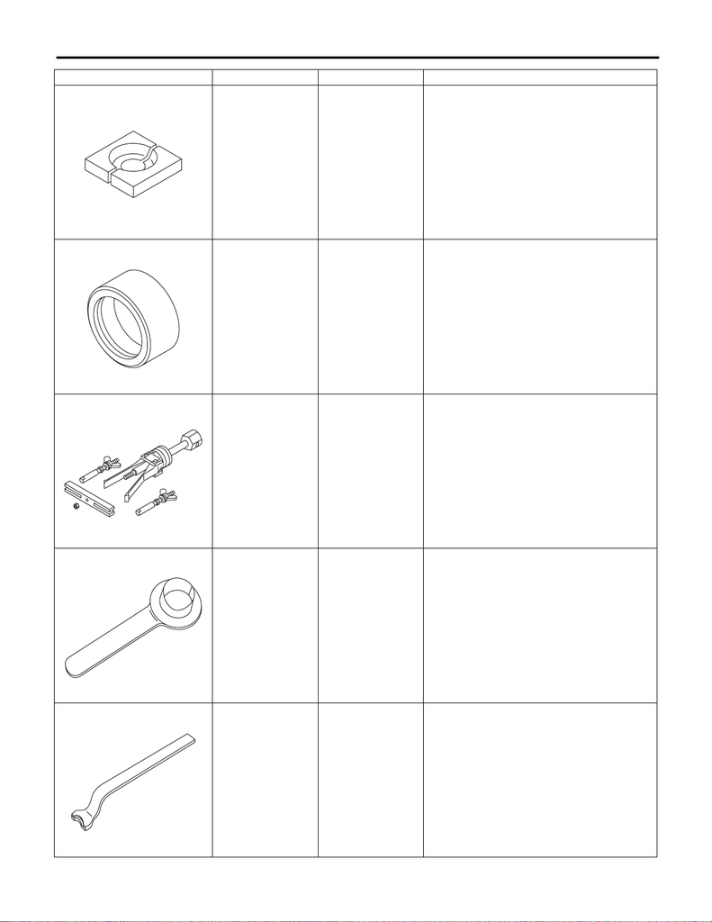

DI-10

General Description

DIFFERENTIALS

398517700 REPLACER Used for removing rear bearing cone.

398487700 DRIFT Used for installing side bearing cone.

398527700 PULLER ASSY • Used for removing front oil seal.

• Used for removing the side bearing race.

28099PA090 OIL SEAL PROTEC-

TOR

Used for installing the rear drive shaft to the rear

differential. (For oil seal protection)

28099PA100 DRIVE SHAFT

REMOVER

Used for removing the rear drive shaft from rear

differential.

ILLUSTRATION TOOL NUMBER DESCRIPTION REMARKS

ST-398517700

ST-398487700

ST-398527700

ST28099PA090

ST28099PA100

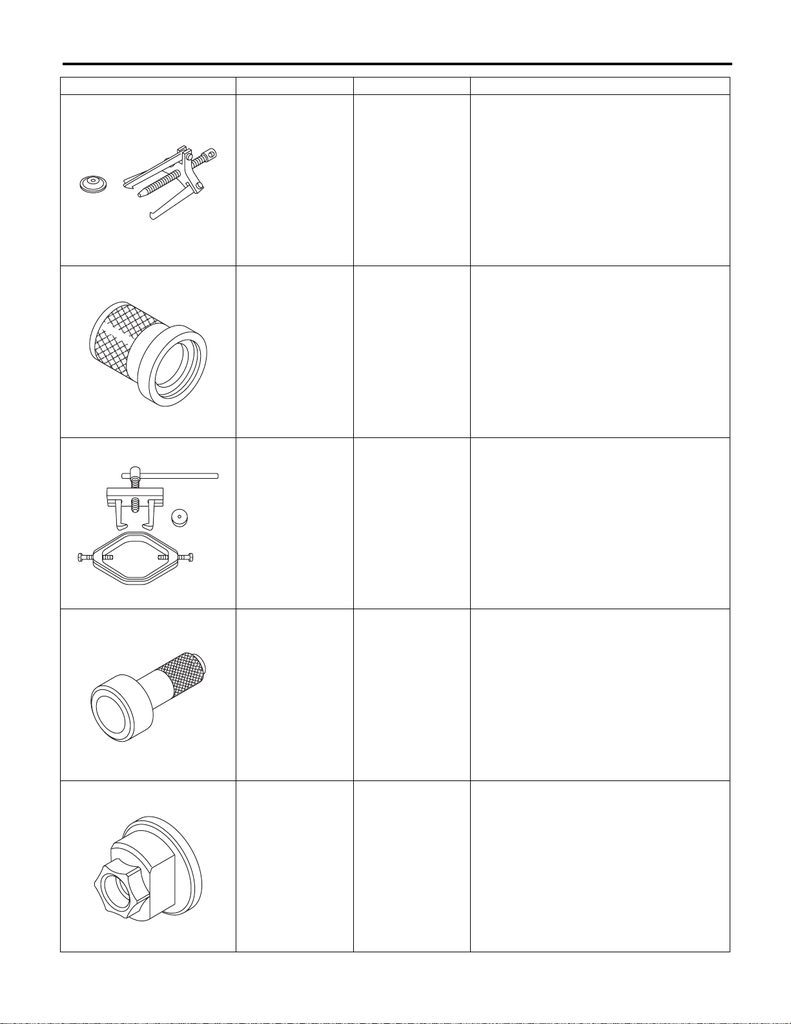

DI-11

General Description

DIFFERENTIALS

399703600 PULLER ASSY Used for removing companion flange.

899874100 INSTALLER Used for installing the companion flange.

18759AA000 PULLER ASSY Used for removing the side bearing cone.

398417700 DRIFT Used for installing side bearing race.

498937110 HOLDER DRIVE

PINION

Used for installing the pilot bearing and the com-

panion flange. (T-type (H5))

ILLUSTRATION TOOL NUMBER DESCRIPTION REMARKS

ST-399703600

ST-899874100

ST18759AA000

ST-398417700

ST-498937110

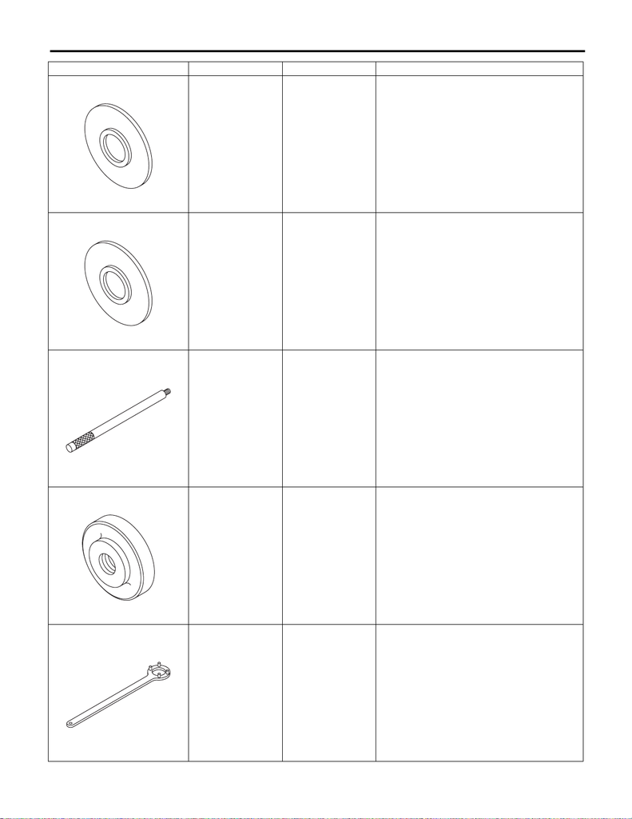

DI-12

General Description

DIFFERENTIALS

18674AA000 INSTALLER Used for installing the rear bearing cone. (T-type

(H5))

398177700 INSTALLER Used for installing the rear bearing cone. (T-type

(B1, B2))

398477701 HANDLE Used for installing the front and rear bearing

races. (T-type (B1, B2))

398477703 DRIFT 2 Used for installing the rear bearing race. (T-type

(B1, B2))

498427200 FLANGE WRENCH Used for stopping rotation of companion flange

when removing and tightening self-lock nut. (T-

type (B1, B2))

ILLUSTRATION TOOL NUMBER DESCRIPTION REMARKS

ST18674AA000

ST-398177700

ST-398477701

ST-398477703

ST-498427200

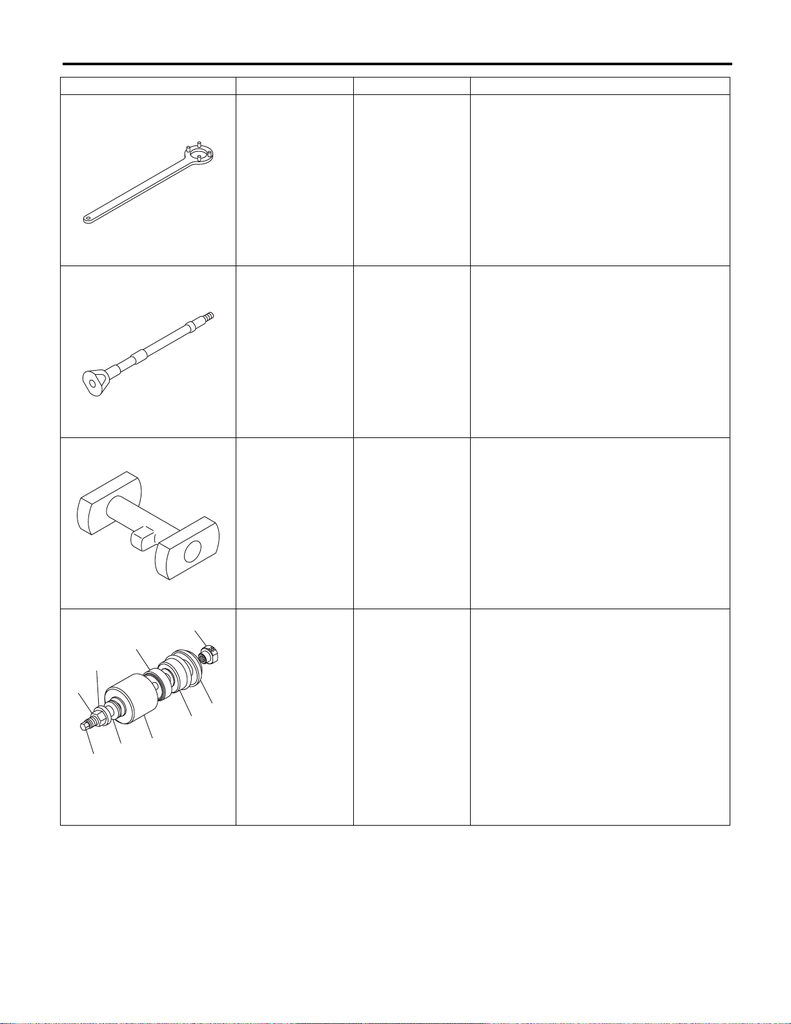

DI-13

General Description

DIFFERENTIALS

18633AA000 WRENCH COMPL Used for preventing rotation of companion flange

when loosening and tightening self-lock nut. (T-

type (H5))

398507702 DUMMY SHAFT Used for adjusting pinion height and preload. (T-

type (B1, B2))

398507701 DIFFERENTIAL

CARRIER GAUGE

Used for adjusting pinion height. (T-type (B1,

B2))

41399FG001 SPECIAL TOOL

ASSY

• Used for removing and installing the rear dif-

ferential mount bushing.

• Use (1), (3), (5), (6), (7), (8) and (9) for

removal.

• Use (2), (4), (5), (6), (7), (8) and (9) for installa-

tion.

(1) SPECIAL TOOL A (41399FG010)

(2) SPECIAL TOOL B (41399FG020)

(3) SPECIAL TOOL C (41399FG031)

(4) SPECIAL TOOL D (41399FG041)

(5) SPECIAL TOOL SLEEVE (41399FG050)

(6) SPECIAL TOOL RING (41399FG061)

(7) SPECIAL TOOL NUT (41399FG070)

(8) SPECIAL TOOL BEARING (41399FG080)

(9) SPECIAL TOOL SHAFT (41399FG091)

ILLUSTRATION TOOL NUMBER DESCRIPTION REMARKS

ST18633AA000

ST-398507702

ST-398507701

ST41399FG001

(1)

(2)

(3)

(4)

(5)

(6)

(7)

(8)

(9)

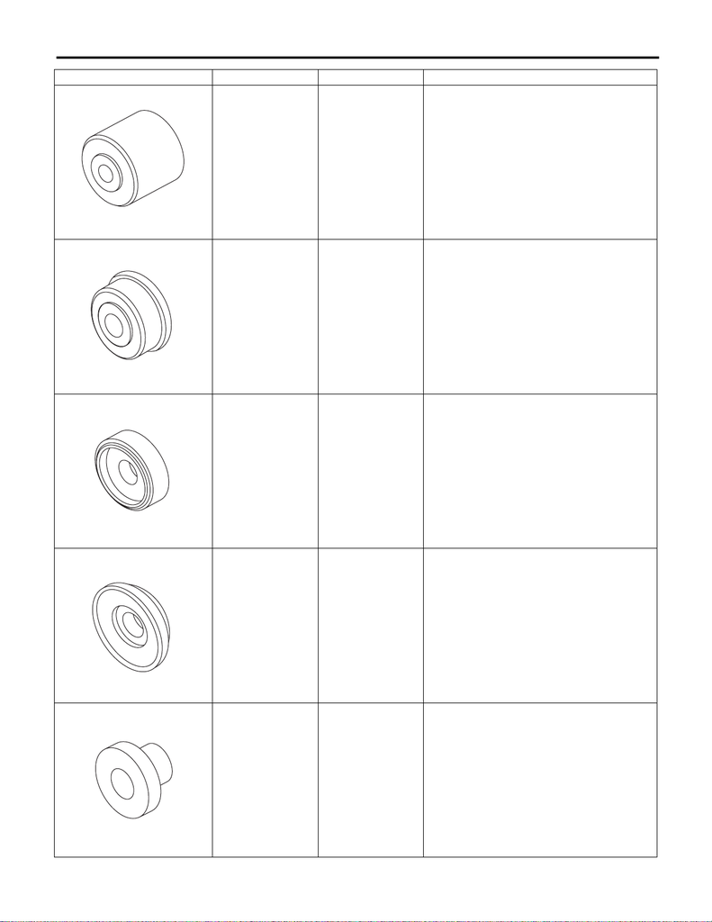

DI-14

General Description

DIFFERENTIALS

41399FG010 SPECIAL TOOL A • Used for removing the rear differential mount

bushing.

• For combination of tools for removal, refer to

“SPECIAL TOOL ASSY (41399FG001)”.

41399FG020 SPECIAL TOOL B • Used for installing the rear differential mount

bushing.

• For combination of tools for installation, refer

to “SPECIAL TOOL ASSY (41399FG001)”.

41399FG031 SPECIAL TOOL C • Used for removing the rear differential mount

bushing.

• For combination of tools for removal, refer to

“SPECIAL TOOL ASSY (41399FG001)”.

41399FG041 SPECIAL TOOL D • Used for installing the rear differential mount

bushing.

• For combination of tools for installation, refer

to “SPECIAL TOOL ASSY (41399FG001)”.

41399FG050 SPECIAL TOOL

SLEEVE

• Used for removing and installing the rear dif-

ferential mount bushing.

• For combination of tools for removal and instal-

lation, refer to “SPECIAL TOOL ASSY

(41399FG001)”.

ILLUSTRATION TOOL NUMBER DESCRIPTION REMARKS

ST41399FG010

ST41399FG020

ST41399FG031

ST41399FG041

ST41399FG050

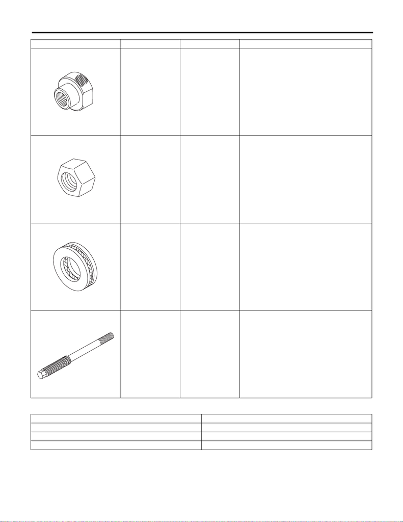

DI-15

General Description

DIFFERENTIALS

2. GENERAL TOOL

41399FG061 SPECIAL TOOL

RING

• Used for removing and installing the rear dif-

ferential mount bushing.

• For combination of tools for removal and instal-

lation, refer to “SPECIAL TOOL ASSY

(41399FG001)”.

41399FG070 SPECIAL TOOL

NUT

• Used for removing and installing the rear dif-

ferential mount bushing.

• For combination of tools for removal and instal-

lation, refer to “SPECIAL TOOL ASSY

(41399FG001)”.

41399FG080 SPECIAL TOOL

BEARING

• Used for removing and installing the rear dif-

ferential mount bushing.

• For combination of tools for removal and instal-

lation, refer to “SPECIAL TOOL ASSY

(41399FG001)”.

41399FG091 SPECIAL TOOL

SHAFT

• Used for removing and installing the rear dif-

ferential mount bushing.

• For combination of tools for removal and instal-

lation, refer to “SPECIAL TOOL ASSY

(41399FG001)”.

TOOL NAME REMARKS

Transmission jack Used for removing and installing the rear differential.

Puller Used for removing the side bearing retainer.

Thickness gauge Used for measuring clearance.

ILLUSTRATION TOOL NUMBER DESCRIPTION REMARKS

ST41399FG061

ST41399FG070

ST41399FG080

ST41399FG091